# Load and Plot Kansas Inactive Voter Percentages by County

Earl F Glynn watchdoglab.substack.com/

2026-05-19

# 1 Setup

## 1.1

## 1.2 Constants

```r
FILE_PREFIX   <- "x"    # no spaces
```

```r
EXCEL_LIMIT <- 2^20
```

## 1.3 Packages

```r
library(tidyverse)
```

```r
library(lubridate)
```

Display formatting

```r
library(kableExtra)  # kable_styling
```

```r
#library(IRdisplay)   # display_html (needed in Jupyter notebooks)
```

I/O

```r
library(readxl)      # read_xlsx
```

```r
library(readr)       # write_csv
library(writexl)     # write_xlsx
```

Graphics

```r
library(RColorBrewer) # brewer.pal
library(scales)       # comma, comma_format
```

```r
library(gplots)       # heatmap.2
```

Utilities

```r
library(downloader)  # download
```

```r
library(tools)       # md5sum
```

## 1.4 ggplot theme

[ggplot Themes Gallery](https://www.datanovia.com/en/blog/ggplot-themes-gallery/)

```r
theme_set(theme_minimal() +

          theme(axis.text             = element_text(size = 12),
                axis.title            = element_text(size = 14),

                legend.position       = "bottom",

                plot.caption          = element_text(hjust = c(0.0,1.0),
                                                     size = 10),
                plot.caption.position = "plot",

                plot.title.position   = "plot",

                strip.background      = element_rect(fill = "aliceblue"),
                strip.text            = element_text(size = 14),

                title                 = element_text(size = 14)))
```

```r
COLOR_BAR     <- "skyblue"
COLOR_OUTLINE <- "grey80"
```

## 1.5 Helper functions

```r
Show <- function(data, caption="", bigMark="",
                 height = NULL, width = NULL, ...)
{
  data                                       |>
  kable("html", caption=caption,
        format.args=list(big.mark=bigMark))  |>
  kable_styling(bootstrap_options=c("striped", "bordered", "condensed"),
                position="left",
                full_width=FALSE, ...)       |>
  scroll_box(height = height, width = width)
}
```

# 2 Voter file summaries

```r
voterFileSummary <-
  read_xlsx("../Stats-from-Voter-Files/Kansas-Voter-Counts-2021-09-02-thru-2026-05-04.xlsx") |>
  select(Geography, Name, Date, InactivePercent) |>
  mutate(Date = ymd(Date))

glimpse(voterFileSummary)
```

```
Rows: 2,014
Columns: 4
$ Geography       <chr> "County", "County", "County", "County", "County", "Cou…
$ Name            <chr> "Allen", "Allen", "Allen", "Allen", "Allen", "Allen", …
$ Date            <date> 2021-09-02, 2022-01-26, 2022-07-01, 2022-09-13, 2023-…
$ InactivePercent <dbl> 5.96, 5.74, 9.40, 8.77, 8.45, 8.40, 6.29, 6.33, 6.29, …
```

```r
c(min(voterFileSummary$Date), max(voterFileSummary$Date))
```

```
[1] "2021-09-02" "2026-05-04"
```

# 3 SoS Summary File Background

Assumes completion of `1-Download-Monthly-County-Inactive-Lists.html` to download files.

From KS SoS Voter Registration Statistics Dashboard https://www.sos.ks.gov/elections/voter-registration-statistics.html

Inspection of files across months and years shows inconsistencies among files.

# 4 List of SoS files

```r
file <-
  tibble(
          Filename =
            list.files(
                        path = "Data",
                        pattern = glob2rx("*-Percentage-of-Inactive-Voters-by-County.xlsx")
                      )
        ) |>
  mutate(
          Date   = ymd(str_sub(Filename, 1, 10)),
          Rows   = NA_integer_,
          Cols   = NA_integer_,
          header = NA_character_,
          types  = NA_character_
        )

dim(file)
```

```
[1] 29  6
```

# 5 First Look

How many rows and columns

```r
for (i in 1:nrow(file))
{
  cat(i, as.character(file$Date[i]), "\n")
  set <- read_xlsx(paste0("Data/", file$Filename[i]))
  file$Rows[i]   <- nrow(set)
  file$Cols[i]   <- ncol(set)
  file$header[i] <- str_flatten(names(set), collapse = "|")
  file$types     <- str_flatten(sapply(set, typeof), collapse = "|")
}
```

```
1 2021-06-01
2 2021-07-01
3 2021-08-01
4 2021-09-01
5 2021-11-01
6 2021-12-01
7 2022-01-01
8 2022-08-01
```

```
9 2023-11-01
```

```
10 2023-12-01
```

```
11 2024-01-01
```

```
12 2024-02-01
```

```
13 2024-03-01
```

```
14 2024-04-01
```

```
15 2024-06-01
```

```
16 2025-01-01
```

```
17 2025-02-01
```

```
18 2025-04-01
```

```
19 2025-06-01
```

```
20 2025-07-01
```

```
21 2025-09-01
```

```
22 2025-10-01
```

```
23 2025-11-01
```

```
24 2025-12-01
```

```
25 2026-01-01
26 2026-02-01
27 2026-03-01
28 2026-04-01
29 2026-05-01
```

Introuction of new name “…1” caused by missing County name in “Old” format files

```r
file |> Show()
```

| Filename | Date | Rows | Cols | header | types |
| --- | --- | --- | --- | --- | --- |
| 2021-06-01-Percentage-of-Inactive-Voters-by-County.xlsx | 2021-06-01 | 108 | 4 | COUNTY\|ALL REGISTERED VOTERS\|INACTIVE VOTERS\|PERCENTAGE OF INACTIVE VOTERS | character\|character\|character\|double\|double |
| 2021-07-01-Percentage-of-Inactive-Voters-by-County.xlsx | 2021-07-01 | 108 | 4 | COUNTY\|ALL REGISTERED VOTERS\|INACTIVE VOTERS\|PERCENTAGE OF INACTIVE VOTERS | character\|character\|character\|double\|double |
| 2021-08-01-Percentage-of-Inactive-Voters-by-County.xlsx | 2021-08-01 | 108 | 4 | 16464\|ALL REGISTERED VOTERS\|INACTIVE VOTERS\|PERCENTAGE OF INACTIVE VOTERS | character\|character\|character\|double\|double |
| 2021-09-01-Percentage-of-Inactive-Voters-by-County.xlsx | 2021-09-01 | 108 | 4 | 16022\|ALL REGISTERED VOTERS\|INACTIVE VOTERS\|PERCENTAGE OF INACTIVE VOTERS | character\|character\|character\|double\|double |
| 2021-11-01-Percentage-of-Inactive-Voters-by-County.xlsx | 2021-11-01 | 108 | 4 | 16000\|ALL REGISTERED VOTERS\|INACTIVE VOTERS\|PERCENTAGE OF INACTIVE VOTERS | character\|character\|character\|double\|double |
| 2021-12-01-Percentage-of-Inactive-Voters-by-County.xlsx | 2021-12-01 | 108 | 4 | 16000\|ALL REGISTERED VOTERS\|INACTIVE VOTERS\|PERCENTAGE OF INACTIVE VOTERS | character\|character\|character\|double\|double |
| 2022-01-01-Percentage-of-Inactive-Voters-by-County.xlsx | 2022-01-01 | 108 | 4 | 16027\|ALL REGISTERED VOTERS\|INACTIVE VOTERS\|PERCENTAGE OF INACTIVE VOTERS | character\|character\|character\|double\|double |
| 2022-08-01-Percentage-of-Inactive-Voters-by-County.xlsx | 2022-08-01 | 108 | 4 | …1\|ALL REGISTERED VOTERS\|INACTIVE VOTERS\|PERCENTAGE OF INACTIVE VOTERS | character\|character\|character\|double\|double |
| 2023-11-01-Percentage-of-Inactive-Voters-by-County.xlsx | 2023-11-01 | 108 | 4 | …1\|ALL REGISTERED VOTERS\|INACTIVE VOTERS\|PERCENTAGE OF INACTIVE VOTERS | character\|character\|character\|double\|double |
| 2023-12-01-Percentage-of-Inactive-Voters-by-County.xlsx | 2023-12-01 | 108 | 4 | …1\|ALL REGISTERED VOTERS\|INACTIVE VOTERS\|PERCENTAGE OF INACTIVE VOTERS | character\|character\|character\|double\|double |
| 2024-01-01-Percentage-of-Inactive-Voters-by-County.xlsx | 2024-01-01 | 108 | 4 | …1\|ALL REGISTERED VOTERS\|INACTIVE VOTERS\|PERCENTAGE OF INACTIVE VOTERS | character\|character\|character\|double\|double |
| 2024-02-01-Percentage-of-Inactive-Voters-by-County.xlsx | 2024-02-01 | 108 | 4 | …1\|ALL REGISTERED VOTERS\|INACTIVE VOTERS\|PERCENTAGE OF INACTIVE VOTERS | character\|character\|character\|double\|double |
| 2024-03-01-Percentage-of-Inactive-Voters-by-County.xlsx | 2024-03-01 | 108 | 4 | …1\|ALL REGISTERED VOTERS\|INACTIVE VOTERS\|PERCENTAGE OF INACTIVE VOTERS | character\|character\|character\|double\|double |
| 2024-04-01-Percentage-of-Inactive-Voters-by-County.xlsx | 2024-04-01 | 108 | 4 | …1\|ALL REGISTERED VOTERS\|INACTIVE VOTERS\|PERCENTAGE OF INACTIVE VOTERS | character\|character\|character\|double\|double |
| 2024-06-01-Percentage-of-Inactive-Voters-by-County.xlsx | 2024-06-01 | 108 | 4 | …1\|ALL REGISTERED VOTERS\|INACTIVE VOTERS\|PERCENTAGE OF INACTIVE VOTERS | character\|character\|character\|double\|double |
| 2025-01-01-Percentage-of-Inactive-Voters-by-County.xlsx | 2025-01-01 | 108 | 4 | …1\|ALL REGISTERED VOTERS\|INACTIVE VOTERS\|PERCENTAGE OF INACTIVE VOTERS | character\|character\|character\|double\|double |
| 2025-02-01-Percentage-of-Inactive-Voters-by-County.xlsx | 2025-02-01 | 108 | 4 | …1\|ALL REGISTERED VOTERS\|INACTIVE VOTERS\|PERCENTAGE OF INACTIVE VOTERS | character\|character\|character\|double\|double |
| 2025-04-01-Percentage-of-Inactive-Voters-by-County.xlsx | 2025-04-01 | 108 | 4 | …1\|ALL REGISTERED VOTERS\|INACTIVE VOTERS\|PERCENTAGE OF INACTIVE VOTERS | character\|character\|character\|double\|double |
| 2025-06-01-Percentage-of-Inactive-Voters-by-County.xlsx | 2025-06-01 | 108 | 4 | …1\|ALL REGISTERED VOTERS\|INACTIVE VOTERS\|PERCENTAGE OF INACTIVE VOTERS | character\|character\|character\|double\|double |
| 2025-07-01-Percentage-of-Inactive-Voters-by-County.xlsx | 2025-07-01 | 108 | 4 | …1\|ALL REGISTERED VOTERS\|INACTIVE VOTERS\|PERCENTAGE OF INACTIVE VOTERS | character\|character\|character\|double\|double |
| 2025-09-01-Percentage-of-Inactive-Voters-by-County.xlsx | 2025-09-01 | 108 | 4 | …1\|ALL REGISTERED VOTERS\|INACTIVE VOTERS\|PERCENTAGE OF INACTIVE VOTERS | character\|character\|character\|double\|double |
| 2025-10-01-Percentage-of-Inactive-Voters-by-County.xlsx | 2025-10-01 | 108 | 4 | …1\|ALL REGISTERED VOTERS\|INACTIVE VOTERS\|PERCENTAGE OF INACTIVE VOTERS | character\|character\|character\|double\|double |
| 2025-11-01-Percentage-of-Inactive-Voters-by-County.xlsx | 2025-11-01 | 108 | 4 | …1\|ALL REGISTERED VOTERS\|INACTIVE VOTERS\|PERCENTAGE OF INACTIVE VOTERS | character\|character\|character\|double\|double |
| 2025-12-01-Percentage-of-Inactive-Voters-by-County.xlsx | 2025-12-01 | 108 | 4 | …1\|ALL REGISTERED VOTERS\|INACTIVE VOTERS\|PERCENTAGE OF INACTIVE VOTERS | character\|character\|character\|double\|double |
| 2026-01-01-Percentage-of-Inactive-Voters-by-County.xlsx | 2026-01-01 | 107 | 5 | Date\|County\|ALL REGISTERED VOTERS\|INACTIVE VOTERS\|PERCENTAGE OF INACTIVE VOTERS | character\|character\|character\|double\|double |
| 2026-02-01-Percentage-of-Inactive-Voters-by-County.xlsx | 2026-02-01 | 106 | 6 | Date\|County\|Active\|Inactive\|Total\|% of Inactive Voters | character\|character\|character\|double\|double |
| 2026-03-01-Percentage-of-Inactive-Voters-by-County.xlsx | 2026-03-01 | 106 | 5 | County\|Active\|Inactive\|Total\|Percentage of Inactive Voters | character\|character\|character\|double\|double |
| 2026-04-01-Percentage-of-Inactive-Voters-by-County.xlsx | 2026-04-01 | 106 | 5 | County\|Active\|Inactive\|Total Registered Voters\|Percentage of Inactive Voters | character\|character\|character\|double\|double |
| 2026-05-01-Percentage-of-Inactive-Voters-by-County.xlsx | 2026-05-01 | 106 | 5 | County\|Active\|Inactive\|Total Registered Voters\|Percentage of Inactive Voters | character\|character\|character\|double\|double |

# 6 Deal with variety of formats

Arbitrary changes made over time to the same data.

Introduce consistency among the files. Standardize on names used starting in March 2026.

The number of Rows and Cols identifies file format.

```r
readSoSFile <- function(index, file, DataPath = "Data/")
{
  Filename <- paste0(DataPath, file$Filename[index])
  DataDate <- file$Date[index]

  cat(index, as.character(DataDate), "\n")

  set <- read_xlsx(Filename)

  # "Old" format:  2021-06-01 through 2025-12-01
  if ( (nrow(set) == 108) && (ncol(set) == 4) )
  {
    # Assign "standard" names
    names(set) <- c("County", "Total", "Inactive", "InactivePercent")

    set$County[nrow(set)] <- "KANSAS"    # label for stat row is missing in original
  }

  # "New" format 1:  2026-01-01 only known case
  if ( (nrow(set) == 107) && (ncol(set) == 5) )
  {
    # Assign "standard" names
    names(set) <- c("Date", "County", "Total", "Inactive", "InactivePercent")

    set <- set |> select(-Date)  # Remove since file datestamp added below for all

    set$County[nrow(set)] <- "KANSAS"    # label for stat row is missing in original
  }

  # "New" format 2:  2026-02-01 only known case
  if ( (nrow(set) == 106) && (ncol(set) == 6) )
  {
    # Assign "standard" names
    names(set) <- c("Date", "County", "Active", "Inactive", "Total", "InactivePercent")
    set <- set |> select(-Date)  # Remove since file datestamp added below for all
    set$County[nrow(set)] <- "KANSAS"    # Replace "Grand Total"
  }

  # "New" format 3:  2026-03-01 and later
  if ( (nrow(set) == 106) && (ncol(set) == 5) )
  {
    # Assign "standard" names
    names(set) <- c("County", "Active", "Inactive", "Total", "InactivePercent")
    set$County[nrow(set)] <- "KANSAS"    # Replace "Grand Total"

    # This is needed for 2026-05-01 data; unclear why character numbers in that file
    set <-
      set |>
      mutate(
              Active   = as.numeric(Active),
              Inactive = as.numeric(Inactive)
            )

  }

  # Add DataDate to this batch
  set <-
    set                     |>
    filter(!is.na(County))  |>  # get rid of blank lines
    mutate(Date = DataDate) |>
    relocate(Date)

  set$County[nrow(set)] <- "KANSAS"    # label for stat row is missing in "old";
                                       # "Grand Total" in "new"

  invisible(set)
}
```

# 7 Explore

```r
index <- nrow(file)
index <- 29
Filename <- paste0("Data/", file$Filename[index])
DataDate <- file$Date[index]
c(Filename, as.character(DataDate))
```

```
[1] "Data/2026-05-01-Percentage-of-Inactive-Voters-by-County.xlsx"
[2] "2026-05-01"
```

```r
inactive <- readSoSFile(index, file)
```

```
29 2026-05-01
```

```r
glimpse(inactive)
```

```
Rows: 106
Columns: 6
$ Date            <date> 2026-05-01, 2026-05-01, 2026-05-01, 2026-05-01, 2026-…
$ County          <chr> "Allen", "Anderson", "Atchison", "Barber", "Barton", "…
$ Active          <dbl> 7848, 4655, 9927, 2729, 14446, 11405, 5485, 41524, 181…
$ Inactive        <dbl> 1039, 1161, 1180, 112, 2649, 1305, 1148, 8546, 56, 374…
$ Total           <dbl> 8887, 5816, 11107, 2841, 17095, 12710, 6633, 50070, 18…
$ InactivePercent <dbl> 0.11691234, 0.19962173, 0.10623931, 0.03942274, 0.1549…
```

```r
inactive |> head() |> Show()
```

| Date | County | Active | Inactive | Total | InactivePercent |
| --- | --- | --- | --- | --- | --- |
| 2026-05-01 | Allen | 7848 | 1039 | 8887 | 0.1169123 |
| 2026-05-01 | Anderson | 4655 | 1161 | 5816 | 0.1996217 |
| 2026-05-01 | Atchison | 9927 | 1180 | 11107 | 0.1062393 |
| 2026-05-01 | Barber | 2729 | 112 | 2841 | 0.0394227 |
| 2026-05-01 | Barton | 14446 | 2649 | 17095 | 0.1549576 |
| 2026-05-01 | Bourbon | 11405 | 1305 | 12710 | 0.1026751 |

```r
inactive |> tail() |> Show()
```

| Date | County | Active | Inactive | Total | InactivePercent |
| --- | --- | --- | --- | --- | --- |
| 2026-05-01 | Washington | 3104 | 507 | 3611 | 0.1404043 |
| 2026-05-01 | Wichita | 1208 | 38 | 1246 | 0.0304976 |
| 2026-05-01 | Wilson | 5061 | 7 | 5068 | 0.0013812 |
| 2026-05-01 | Woodson | 2072 | 180 | 2252 | 0.0799290 |
| 2026-05-01 | Wyandotte | 70872 | 22216 | 93088 | 0.2386559 |
| 2026-05-01 | KANSAS | 1737971 | 270903 | 2008874 | 0.1348532 |

# 8 Long format

## 8.1 Combine all files

Long Format shows all data in original files

```r
KansasInactive <-
  1:nrow(file)                      |>
  purrr::map_dfr(readSoSFile, file) |>
  arrange(County, Date)             |>
  mutate(InactivePercent = 100 * InactivePercent)  |>
  select(Date, County, Total, Active, Inactive, InactivePercent)
```

```
1 2021-06-01
2 2021-07-01
3 2021-08-01
4 2021-09-01
5 2021-11-01
6 2021-12-01
7 2022-01-01
8 2022-08-01
```

```
9 2023-11-01
```

```
10 2023-12-01
```

```
11 2024-01-01
```

```
12 2024-02-01
```

```
13 2024-03-01
```

```
14 2024-04-01
```

```
15 2024-06-01
```

```
16 2025-01-01
```

```
17 2025-02-01
```

```
18 2025-04-01
```

```
19 2025-06-01
```

```
20 2025-07-01
```

```
21 2025-09-01
```

```
22 2025-10-01
```

```
23 2025-11-01
```

```
24 2025-12-01
```

```
25 2026-01-01
26 2026-02-01
27 2026-03-01
28 2026-04-01
29 2026-05-01
```

```r
dim(KansasInactive)
```

```
[1] 3074    6
```

Change “County” to “Name” and add Geography column with values County or State

```r
KansasInactive <-
  KansasInactive         |>
  rename(Name = County)  |>
  mutate(
          Geography = if_else(Name == "KANSAS", "State", "County")
        )                |>
  relocate(Geography, Name) |>
  arrange(Geography, Name, Date)
```

```r
glimpse(KansasInactive)
```

```
Rows: 3,074
Columns: 7
$ Geography       <chr> "County", "County", "County", "County", "County", "Cou…
$ Name            <chr> "Allen", "Allen", "Allen", "Allen", "Allen", "Allen", …
$ Date            <date> 2021-06-01, 2021-07-01, 2021-08-01, 2021-09-01, 2021-…
$ Total           <dbl> 8617, 8623, 8618, 8613, 8608, 8608, 8636, 8730, 8698, …
$ Active          <dbl> NA, NA, NA, NA, NA, NA, NA, NA, NA, NA, NA, NA, NA, NA…
$ Inactive        <dbl> 380, 378, 514, 513, 505, 502, 499, 793, 559, 547, 549,…
$ InactivePercent <dbl> 4.409887, 4.383625, 5.964261, 5.956113, 5.866636, 5.83…
```

```r
write_xlsx(KansasInactive, "Kansas-SoS-Inactive-Voter-Rate-Long-Format.xlsx")
```

```r
c(min(KansasInactive$Date), max(KansasInactive$Date))
```

```
[1] "2021-06-01" "2026-05-01"
```

Make sure all counties and state data present in all files

```r
table(KansasInactive$Name)
```

```
       Allen     Anderson     Atchison       Barber       Barton      Bourbon
          29           29           29           29           29           29
       Brown       Butler        Chase   Chautauqua     Cherokee     Cheyenne
          29           29           29           29           29           29
       Clark         Clay        Cloud       Coffey     Comanche       Cowley
          29           29           29           29           29           29
    Crawford      Decatur    Dickinson     Doniphan      Douglas      Edwards
          29           29           29           29           29           29
         Elk        Ellis    Ellsworth       Finney         Ford     Franklin
          29           29           29           29           29           29
       Geary         Gove       Graham        Grant         Gray      Greeley
          29           29           29           29           29           29
   Greenwood     Hamilton       Harper       Harvey      Haskell     Hodgeman
          29           29           29           29           29           29
     Jackson    Jefferson       Jewell      Johnson       KANSAS       Kearny
          29           29           29           29           29           29
     Kingman        Kiowa      Labette         Lane  Leavenworth      Lincoln
          29           29           29           29           29           29
        Linn        Logan         Lyon       Marion     Marshall    McPherson
          29           29           29           29           29           29
       Meade        Miami     Mitchell   Montgomery       Morris       Morton
          29           29           29           29           29           29
      Nemaha       Neosho         Ness       Norton        Osage      Osborne
          29           29           29           29           29           29
      Ottawa       Pawnee     Phillips Pottawatomie        Pratt      Rawlins
          29           29           29           29           29           29
        Reno     Republic         Rice        Riley        Rooks         Rush
          29           29           29           29           29           29
     Russell       Saline        Scott     Sedgwick       Seward      Shawnee
          29           29           29           29           29           29
    Sheridan      Sherman        Smith     Stafford      Stanton      Stevens
          29           29           29           29           29           29
      Sumner       Thomas        Trego    Wabaunsee      Wallace   Washington
          29           29           29           29           29           29
     Wichita       Wilson      Woodson    Wyandotte
          29           29           29           29
```

## 8.2 High inactive rates

```r
fivenum(KansasInactive$InactivePercent)
```

```
[1]  0.000000  3.298775  5.486521  8.641975 63.282937
```

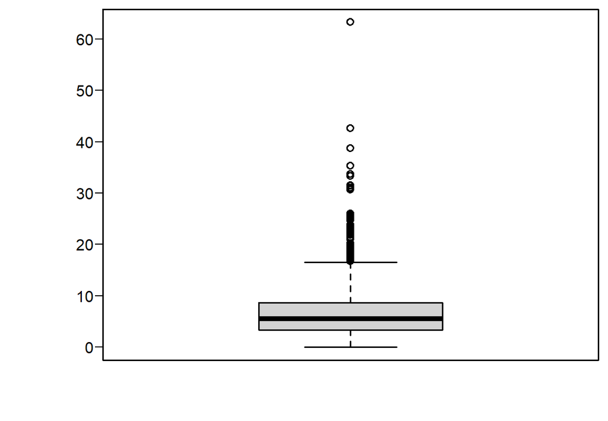

```r
boxplot(KansasInactive$InactivePercent)
```

```r
KansasInactive |>
  filter(InactivePercent > 20) |>
  Show()
```

| Geography | Name | Date | Total | Active | Inactive | InactivePercent |
| --- | --- | --- | --- | --- | --- | --- |
| County | Finney | 2026-03-01 | 20871 | 15513 | 5358 | 25.67199 |
| County | Finney | 2026-04-01 | 20862 | 15445 | 5417 | 25.96587 |
| County | Finney | 2026-05-01 | 20859 | 15452 | 5407 | 25.92166 |
| County | Ford | 2026-01-01 | 16868 | NA | 5323 | 31.55679 |
| County | Ford | 2026-02-01 | 16892 | 11643 | 5249 | 31.07388 |
| County | Ford | 2026-03-01 | 16853 | 11660 | 5193 | 30.81350 |
| County | Ford | 2026-04-01 | 16874 | 11705 | 5169 | 30.63293 |
| County | Ford | 2026-05-01 | 16898 | 11583 | 5315 | 31.45343 |
| County | Grant | 2026-04-01 | 3769 | 3007 | 762 | 20.21756 |
| County | Grant | 2026-05-01 | 3774 | 3014 | 760 | 20.13778 |
| County | Labette | 2026-01-01 | 13699 | NA | 3223 | 23.52726 |
| County | Labette | 2026-02-01 | 13684 | 10516 | 3168 | 23.15113 |
| County | Labette | 2026-03-01 | 13668 | 10546 | 3122 | 22.84167 |
| County | Labette | 2026-04-01 | 13673 | 10567 | 3106 | 22.71630 |
| County | Labette | 2026-05-01 | 13682 | 10197 | 3485 | 25.47142 |
| County | Linn | 2026-04-01 | 7778 | 5820 | 1958 | 25.17357 |
| County | Linn | 2026-05-01 | 7802 | 5845 | 1957 | 25.08331 |
| County | Logan | 2021-09-01 | 1852 | NA | 1172 | 63.28294 |
| County | Neosho | 2026-05-01 | 11063 | 8747 | 2316 | 20.93465 |
| County | Norton | 2026-05-01 | 3454 | 2727 | 727 | 21.04806 |
| County | Osage | 2026-03-01 | 12247 | 9197 | 3050 | 24.90406 |
| County | Osage | 2026-04-01 | 12237 | 9205 | 3032 | 24.77731 |
| County | Osage | 2026-05-01 | 12256 | 9236 | 3020 | 24.64099 |
| County | Rice | 2023-12-01 | 6469 | NA | 1428 | 22.07451 |
| County | Rice | 2024-01-01 | 6481 | NA | 1418 | 21.87934 |
| County | Rice | 2024-02-01 | 6525 | NA | 1394 | 21.36398 |
| County | Rice | 2024-03-01 | 6547 | NA | 1380 | 21.07836 |
| County | Seward | 2026-02-01 | 11325 | 8827 | 2498 | 22.05740 |
| County | Seward | 2026-03-01 | 11307 | 7496 | 3811 | 33.70478 |
| County | Seward | 2026-04-01 | 11296 | 7528 | 3768 | 33.35694 |
| County | Seward | 2026-05-01 | 11331 | 7325 | 4006 | 35.35434 |
| County | Sumner | 2022-08-01 | 16953 | NA | 3790 | 22.35593 |
| County | Wabaunsee | 2021-08-01 | 5251 | NA | 2236 | 42.58237 |
| County | Wabaunsee | 2021-09-01 | 5221 | NA | 2020 | 38.68991 |
| County | Wyandotte | 2026-02-01 | 92763 | 72250 | 20513 | 22.11334 |
| County | Wyandotte | 2026-03-01 | 92872 | 72553 | 20319 | 21.87850 |
| County | Wyandotte | 2026-04-01 | 92920 | 72024 | 20896 | 22.48816 |
| County | Wyandotte | 2026-05-01 | 93088 | 70872 | 22216 | 23.86559 |

# 9 Wide format

Wide format will show only `InactivePercent`. (Could make wide format for other quantities if needed.)

Wide format can be used for heatmap analysis showing which counties have similar patterns, and to create sparklines for all counties in Excel.

```r
KansasInactiveWide <-
  KansasInactive |>
  select(Geography, Name, Date, Date, InactivePercent) |>
  pivot_wider(names_from  = Date,
              values_from = InactivePercent)

dim(KansasInactiveWide)
```

```
[1] 106  31
```

```r
write_xlsx(KansasInactiveWide, "Kansas-SoS-Inactive-Voter-Rate-Wide-Format.xlsx")
```

## 9.1 Heatmap

```r
inactiveMatrix <-
  KansasInactiveWide        |>
  select(-Geography, -Name) |>
  as.matrix()

dim(inactiveMatrix)
```

```
[1] 106  29
```

```r
dimnames(inactiveMatrix) <-
  list(
         KansasInactiveWide$Name,
         names(KansasInactiveWide)[c(-1, -2)] |> str_sub(3, 7)
      )
```

```r
inactiveMatrix[1:5, 1:5]
```

```
             21-06     21-07     21-08     21-09     21-11
Allen     4.409887  4.383625  5.964261  5.956113  5.866636
Anderson  5.067064  5.066120  4.995357  6.805118  6.421678
Atchison 15.861164 15.776520 15.717447 15.656731 18.910964
Barber    2.064694  2.062564  1.995871  3.317208  3.228046
Barton    4.748875  4.731248  4.719388  3.738609  3.456250
```

```r
colorBreaks <- c(0, 2, 4, 6, 8, 10, 12, 14, 16, 20, 30, 40, 50, 64)
colorBreaks
```

```
 [1]  0  2  4  6  8 10 12 14 16 20 30 40 50 64
```

```r
colorPalette <-
  c(
     colorRampPalette(c("red",   "white"))(6)[1:5],    # skip last
     colorRampPalette(c("white", "skyblue"))(7)[2:5],  # skip first
     "grey80", "grey64", "grey32", "grey0"
   )

colorPalette
```

```
 [1] "#FF0000" "#FF3333" "#FF6666" "#FF9999" "#FFCCCC" "#EBF6FB" "#D7EEF8"
 [8] "#C3E6F4" "#AFDEF1" "grey80"  "grey64"  "grey32"  "grey0"
```

```r
# layout matrix 1 = heatmap, 2 = row dendrogram, 3 = column dendrogram, 4 = key
# 0 = leaves space
lmat <- rbind( c(0, 3, 3),  # layout matrix
               c(2, 1, 1),
               c(0, 0, 4))

# Layout relative widths
lwid <- c(1, 4, 6)    # entry for each column in layout matrix 3-4-4

# Layout relative heights
# relative height of the rows. must have length = nrow(lmat)
lhei <- c(0.15, 5, 0.3)    # entry for each row in layout matrix
```

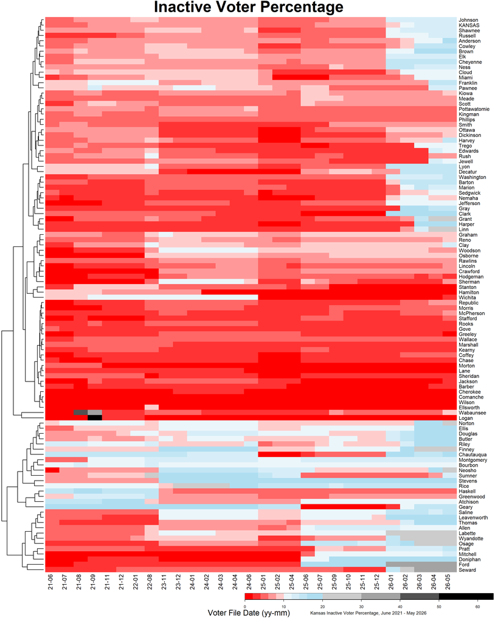

```r
oldPar <- par(mar = c(5, 0, 2, 0))

heatmap.2(
           inactiveMatrix,
           scale      = "none",
           dendrogram = "row",
           Colv       = NA,         # suppress reordering of columns

           trace  = "none",         # turns off trace lines inside the heat map
           col    = colorPalette,
           breaks = colorBreaks,

           margins = c(4, 10),      # column and row names

           cexRow = 1.50,
           cexCol = 1.75,

           key.title = NA,           # suppress title
           key.xlab  = "Kansas Inactive Voter Percentage, June 2021 - May 2026 ", ,
           keysize   = 3,
           density.info = "none",    # turns off density plot inside color legend

           lmat = lmat, lwid = lwid, lhei = lhei
         )

title(main     = "Inactive Voter Percentage",
      cex.main = 3,
      sub      = "Voter File Date (yy-mm)",
      cex.sub  = 1.5)

par(oldPar)
```

# 10 Separate State and County Plots

```r
stateStats   <- KansasInactive   |> filter(Geography == "State")
stateVoters  <- voterFileSummary |> filter(Geography == "State")
stateColor   <- "royalblue"

c(min(stateStats$InactivePercent),  max(stateStats$InactivePercent))
```

```
[1]  5.058495 13.485316
```

```r
c(min(stateVoters$InactivePercent), max(stateVoters$InactivePercent))
```

```
[1]  5.62 13.62
```

```r
stateStats |>
  filter(
          InactivePercent == min(stateStats$InactivePercent)
        )  |>
  Show()
```

| Geography | Name | Date | Total | Active | Inactive | InactivePercent |
| --- | --- | --- | --- | --- | --- | --- |
| State | KANSAS | 2025-02-01 | 2000595 | NA | 101200 | 5.058495 |

```r
stateVoters |>
  filter(
          InactivePercent == max(stateVoters$InactivePercent)
        )  |>
  Show()
```

| Geography | Name | Date | InactivePercent |
| --- | --- | --- | --- |
| State | KANSAS | 2026-05-04 | 13.62 |

```r
plotCaptionLeft  <- "Source: Kansas Secretary of State Online Voter Registration Statistics Dashboard (circles); Voter Files (triangles)"
plotCaptionRight <- paste("efg ", format(Sys.time(), "%Y-%m-%d"))
```

```r
countyStats  <- KansasInactive   |> filter(Geography == "County")
countyVoters <- voterFileSummary |> filter(Geography == "County")
countyColor  <- "grey"
```

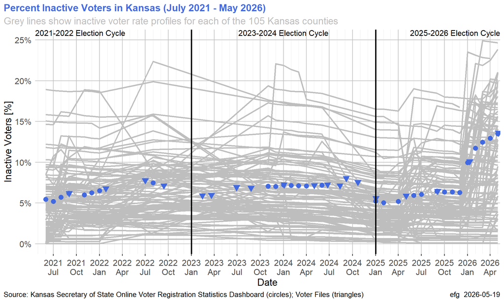

```r
allCountiesPlot <-
  ggplot() +
    geom_line(data = countyStats,
              aes(x = Date,
                  y = InactivePercent,
                  group = Name),
              color = countyColor,
              linewidth = 1      )           +

#    geom_line(data = stateStats,
#              aes(x = Date,
#                  y = InactivePercent),
#              color = stateColor,
#              linewidth = 1)                 +

    geom_point(data = stateStats,
               aes(x = Date,
                   y = InactivePercent),
               color = stateColor,
               size = 3)                     +

    geom_point(data = stateVoters,
               aes(x = Date,
                   y = InactivePercent),
               color = stateColor,
               fill= stateColor,
               size = 3,
               shape = 25)                   +

   scale_y_continuous(
                       limits = c(0, 25),
                       breaks = c( 0,  5, 10, 15, 20,
                                  25, 30, 35, 40),
                       labels = c( "0%",  "5%", "10%", "15%", "20%",
                                   "25%", "30%", "35%", "40%")
                     )                                             +

   geom_vline(xintercept = c(
                              ymd("2023-01-01"),
                              ymd("2025-01-01")
                            ),
              color     = "black",
              linewidth = 1,
              linetype  = "solid"
             )                                                     +

   annotate("text", x = c(
                           -Inf,
                           ymd("2024-01-01"),
                           Inf
                         ),
                    y = Inf,
                    label = c(
                               "2021-2022 Election Cycle",
                               "2023-2024 Election Cycle",
                               "2025-2026 Election Cycle"
                             ),
            color = "black", hjust = c(0.0, 0.5, 1.0),
            vjust = 1, size = 4)                                   +

   scale_x_date(limits = c(ymd("2021-04-20"), ymd("2026-05-10")),
                 date_breaks       = "3 months",
                 date_minor_breaks = "1 month",
                 date_labels = "%Y\n%b",
                 expand = c(0,0))                                  +

   labs(title    = "Percent Inactive Voters in Kansas (July 2021 - May 2026)",
        subtitle = "Grey lines show inactive voter rate profiles for each of the 105 Kansas counties",
        x = "Date",
        y = "Inactive Voters [%]",
        caption = c(plotCaptionLeft, plotCaptionRight))  +
   theme(plot.title         = element_text(size = 14, color = stateColor, face = "bold"),
         plot.subtitle      = element_text(size = 14, color = "grey"),
         axis.ticks.x       = element_line(),
         panel.grid.major.x = element_line(linewidth = 0.5, color = "grey"),
         panel.grid.minor.y = element_blank(),
         panel.grid.major.y = element_line(linewidth = 0.5, color = "grey"))

print(allCountiesPlot)
```

# 11 State only inactive rate based on voter files

```r
voterFiles <-
  read_xlsx("Kansas-Voters-Source-File-Summary-Edited.xlsx") |>
  select(Source, InactivePercent = `%Inactive`)              |>
  mutate(
          Date = ymd(Source),
          InactivePercent = 100 * InactivePercent
        )

glimpse(voterFiles)
```

```
Rows: 47
Columns: 3
$ Source          <chr> "2006-05-17", "2006-12-26", "2007-11-14", "2008-01-28"…
$ InactivePercent <dbl> 5.721917, 8.703376, 9.440613, 9.949793, 11.448830, 9.9…
$ Date            <date> 2006-05-17, 2006-12-26, 2007-11-14, 2008-01-28, 2008-…
```

```r
c(min(voterFiles$Date), max(voterFiles$Date))
```

```
[1] "2006-05-17" "2026-05-04"
```

```r
cycles <- seq( from = ymd("2005-01-01"), to = ymd("2027-01-01"), by = "2 years")
cycles
```

```
 [1] "2005-01-01" "2007-01-01" "2009-01-01" "2011-01-01" "2013-01-01"
 [6] "2015-01-01" "2017-01-01" "2019-01-01" "2021-01-01" "2023-01-01"
[11] "2025-01-01" "2027-01-01"
```

```r
cycleLabels <- seq( from = ymd("2008-01-01"), to = ymd("2026-01-01"), by = "2 years")
cycleLabels
```

```
 [1] "2008-01-01" "2010-01-01" "2012-01-01" "2014-01-01" "2016-01-01"
 [6] "2018-01-01" "2020-01-01" "2022-01-01" "2024-01-01" "2026-01-01"
```

```r
plotCaptionLeft  <- "Source: Kansas Secretary of State Voter Files [2006 - 2026]"
```

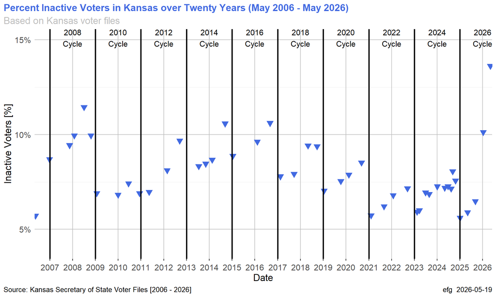

```r
 ggplot() +
     geom_point(data = voterFiles,
               aes(x = Date,
                   y = InactivePercent),
               color = stateColor,
               fill= stateColor,
               size = 3,
               shape = 25)                              +
   scale_y_continuous(
                       limits = c(4, 15),
                       breaks = c( 0,  5, 10, 15, 20,
                                  25, 30, 35, 40),
                       labels = c( "0%",  "5%", "10%", "15%", "20%",
                                   "25%", "30%", "35%", "40%")
                     )                                  +

  geom_vline(xintercept = cycles,
              color     = "black",
              linewidth = 1,
              linetype  = "solid"
             )                                          +

  annotate("text", x = cycleLabels,
                   y = Inf,
                   label = paste0(str_sub(cycleLabels, 1, 4), "\nCycle"),
            color = "black", hjust = 0.5,
            vjust = 1, size = 4)                        +

  scale_x_date(limits = c(ymd("2006-05-01"), ymd("2026-06-01")),
                 date_breaks = "1 year",
                 date_labels = "%Y",
                 expand = c(0,0))                       +
  labs(title    = "Percent Inactive Voters in Kansas over Twenty Years (May 2006 - May 2026)",
       subtitle = "Based on Kansas voter files",
       x = "Date",
       y = "Inactive Voters [%]",
       caption = c(plotCaptionLeft, plotCaptionRight))  +
 theme(plot.title         = element_text(size = 14, color = stateColor, face = "bold"),
         plot.subtitle      = element_text(size = 14, color = "grey"),
         axis.ticks.x       = element_line(),
         panel.grid.minor.x = element_blank(),
         panel.grid.major.x = element_line(linewidth = 0.5, color = "grey"),
        # panel.grid.minor.y = element_blank(),
         panel.grid.major.y = element_line(linewidth = 0.5, color = "grey"))
```

# 12 Epilog

## 12.1

Processing time: 8.8 secs

2026-05-19 2208